#Name: Sweta Kumari #Facebook Friends

#(1) Describe the data structure and identify int and binary variables. #a. Read the FacebookFriends file.

```r
fbfriend<-read.csv("C:\\Users\\Sweta\\Documents\\Data\\FacebookFriends.csv", header=T)
attach(fbfriend)
names(fbfriend)
```

```
##  [1] "Age"          "Photos"       "X..of.Tags"   "Albums"       "Gender"
##  [6] "Emp"          "Profile"      "Cover"        "Orientation"  "Relationship"
## [11] "Posts"        "Replies"      "Children"     "Likes"        "Edu"
## [16] "Events"       "Friends"
```

#b. To determine the data type of each variables, use str function.

```r
str(fbfriend)
```

```
## 'data.frame':    715 obs. of  17 variables:
##  $ Age         : int  57 42 42 55 30 25 28 32 29 25 ...
##  $ Photos      : int  7 531 1396 394 916 241 138 167 922 231 ...
##  $ X..of.Tags  : int  27 241 423 139 231 345 206 581 1702 209 ...
##  $ Albums      : int  5 19 40 48 78 6 15 10 23 8 ...
##  $ Gender      : int  1 0 0 0 1 1 1 1 0 0 ...
##  $ Emp         : int  1 0 1 1 1 1 1 1 1 1 ...
##  $ Profile     : int  1 0 1 1 1 1 0 1 1 1 ...
##  $ Cover       : int  0 0 0 1 1 1 1 0 1 1 ...
##  $ Orientation : int  1 1 1 1 1 1 1 1 1 1 ...
##  $ Relationship: int  1 1 1 1 1 0 0 0 1 0 ...
##  $ Posts       : int  1 5 186 6 412 543 254 236 8 11 ...
##  $ Replies     : int  0 1 31 4 752 654 163 195 9 4 ...
##  $ Children    : int  3 3 2 2 1 0 0 0 1 1 ...
##  $ Likes       : int  21 9 43 187 34 48 151 64 9 29 ...
##  $ Edu         : int  0 0 1 0 0 0 0 0 0 0 ...
##  $ Events      : int  0 1 1 4 2 5 1 3 2 27 ...
##  $ Friends     : int  68 234 727 437 372 552 248 875 636 440 ...
```

#Comment on section1: FacebookFriends is the dataset where number of observations are 715 and number of variables are 17. Here, Friends is dependent or response variable and all other variables are independent or explanatory variable. We have to predict the number of friends on Facebook based on all other independent variables: Age, Photos, # of Tags, Albums, Gender, Emp, Profile, Cover, Orientation, Relationship, Posts, Replies, Children, Likes, Edu, Events.

#Integer variables are Age, Photos, # of Tags, Albums, Posts, Replies, Children, Likes, Events.

#Binary variables are Gender, Emp, Profile, Cover, Orientation, Relationship, Edu.

#(2) Get the mean, median, sample standard deviation, and coefficient of variation for all variables. What do these statistics tell you about the distributions?

#a. Mean of all variable.

```r
sapply(Filter(is.numeric, fbfriend), FUN = mean, na.rm = TRUE)
```

```
##          Age       Photos   X..of.Tags       Albums       Gender          Emp
##   24.4069930  723.9146853  458.0965035   18.9524476    0.5412587    0.7454545
##      Profile        Cover  Orientation Relationship        Posts      Replies
##    0.9174825    0.5076923    0.9566434    0.4923077   37.5790210   34.8167832
##     Children        Likes          Edu       Events      Friends
##    0.2111888  144.8125874    0.2671329    8.8531469  695.8531469
```

#b. Median of all variable.

```r
sapply(Filter(is.numeric, fbfriend), FUN = median, na.rm = TRUE)
```

```
##          Age       Photos   X..of.Tags       Albums       Gender          Emp
##           22          320          250           12            1            1
##      Profile        Cover  Orientation Relationship        Posts      Replies
##            1            1            1            0           15           14
##     Children        Likes          Edu       Events      Friends
##            0           59            0            4          563
```

#c. Standard deviation of all variable

```r
sapply(Filter(is.numeric, fbfriend), FUN = sd, na.rm = TRUE)
```

```
##          Age       Photos   X..of.Tags       Albums       Gender          Emp
##    6.9695783 1265.1123043  720.8354808   22.5028596    0.5179318    0.4359103
##      Profile        Cover  Orientation Relationship        Posts      Replies
##    0.2753441    0.5002908    0.2038012    0.5002908   90.4377952   83.6291584
##     Children        Likes          Edu       Events      Friends
##    0.6515554  261.4147806    0.4427721   24.0026720  599.5279464
```

#d. Co-efficinet of variation of all variable. Define co.var function and sapply function.

```r
co.var <- function(x) (100*sd(x)/mean(x))
sapply(Filter(is.numeric, fbfriend), FUN = co.var)
```

```
##          Age       Photos   X..of.Tags       Albums       Gender          Emp
##     28.55566    174.75986    157.35450    118.73326     95.69024     58.47578
##      Profile        Cover  Orientation Relationship        Posts      Replies
##     30.01083     98.54213     21.30378    101.62157    240.66033    240.19783
##     Children        Likes          Edu       Events      Friends
##    308.51797    180.51938    165.74975    271.12023     86.15725
```

#Comment on Section2: #1. Age: Average age of Facebook user is 24.4 years while median is 22 years. Since, mean is greater than median, most of the data will be distributed on the left side. The standard deviation is 6.96 which is far from mean. Co-efficient of variation is 28.5% is not high and shows the percentage of dispersion of data around the mean.

#2. Photos: Average number of photos is 724 while median is 320. Since, mean is greater than median, most of the data will be distributed on the left side. The standard deviation is 1265.112 which is far from mean. Co-efficient of variation is 174.76% is high and shows the percentage of dispersion of data around the mean.

#3. Number of Tags: Average number of tag is 458 while median is 250. Since, mean is greater than median, most of the data will be distributed on the left side. The standard deviation is 720.8355 which is far from mean. Co-efficient of variation is 157.35% is high and shows the percentage of dispersion of data around the mean.

#4. Albums: Average number of albums is 19 while median is 12. Since, mean is greater than median, most of the data will be distributed on the left side. The standard deviation is 22 which is near mean. Co-efficient of variation is 118.7% is high and shows the percentage of dispersion of data around the mean.

#5. Gender: Male users are more than female users. In the dataset, there is one more entry (2) apart from 0 and 1. Since, description says it is binary variable. I am considering same too.

#6. Emp: Number of employed users is more than (approx. 75%) number of unemployed user in Facebook.

#7. Profile: Most of the Facebook users (approx. 91%) have profile pictures of themselves. Only 9% are using something else on their profile picture.

#8. Cover: Approx. half of the users use cover photo of themselves. Rest of the users use something else on their cover photo.

#9. Orientation: 95.6% users have Sexual orientation as heterosexual.

#10. Relationship: 49% of the users shows that they are in relationship. Rest 51% do not show their relationship status as in relationship.

#11. Posts: Average number of posts are 38 (approx.) while median is 15. Since, mean is greater than median, most of the data will be distributed on the left side. The standard deviation is 90.4 which is far from mean. Co-efficient of variation is 240.6 % is high and shows the percentage of dispersion of data around the mean.

#12. Replies: Average number of replies from the individual on the ‘timeline’ 35 while median is 14. Since, mean is greater than median, most of the data will be distributed on the left side. The standard deviation is 83.6 which is far from mean. Co-efficient of variation is 240.2 % is high and shows the percentage of dispersion of data around the mean.

#13. Children: Average number of children is 0.211 which means most of the users doesn’t have kids and median shows 0. The standard deviation is 0.651 which is near mean. Co-efficient of variation is 308.5 % is high and shows the percentage of dispersion of data around the mean.

#14. Likes: Average number of likes in the main page is 145 while median is 59. Since, mean is greater than median, most of the data will be distributed on the left side. The standard deviation is 261.4 which is far from mean. Co-efficient of variation is 180.5 % is high and shows the percentage of dispersion of data around the mean.

#15. Edu: 26.7% of users mention their high school or less information. The standard deviation is 0.44 which is not far from mean. Co-efficient of variation is 165.7 % is high and shows the percentage of dispersion of data around the mean.

#16. Events: Average number of events listed is 8.8 while median is 4. The standard deviation is 24 which is far from mean. Co-efficient of variation is 271.12 % is high and shows the percentage of dispersion of data around the mean.

#17. Friends: Average number of friends is 696 while median is 563. The standard deviation is 599.5 which is not too far from mean. Co-efficient of variation is 86.15 % is high and shows the percentage of dispersion of data around the mean.

#(3)Choose all non-binary variables and create frequency tabulations, boxplots, and histograms for all. Describe the distribution for each. #a. Create frequency tabulations

```r
library(summarytools)
library(DT)
datatable(freq(fbfriend$Age)) %>% formatRound('% Valid', digits=2)%>%  formatRound('% Valid Cum.',digits=2) %>% formatRound('% Total', digits=2) %>% formatRound('% Total Cum.', digits=2)
```

|  | Freq | % Valid | % Valid Cum. | % Total | % Total Cum. |
| --- | --- | --- | --- | --- | --- |
| 13 | 1 | 0.13986013986014 | 0.13986013986014 | 0.13986013986014 | 0.13986013986014 |
| 14 | 1 | 0.13986013986014 | 0.27972027972028 | 0.13986013986014 | 0.27972027972028 |
| 15 | 5 | 0.699300699300699 | 0.979020979020979 | 0.699300699300699 | 0.979020979020979 |
| 16 | 5 | 0.699300699300699 | 1.67832167832168 | 0.699300699300699 | 1.67832167832168 |
| 17 | 13 | 1.81818181818182 | 3.4965034965035 | 1.81818181818182 | 3.4965034965035 |
| 18 | 29 | 4.05594405594406 | 7.55244755244755 | 4.05594405594406 | 7.55244755244755 |
| 19 | 31 | 4.33566433566433 | 11.8881118881119 | 4.33566433566433 | 11.8881118881119 |
| 20 | 92 | 12.8671328671329 | 24.7552447552448 | 12.8671328671329 | 24.7552447552448 |
| 21 | 96 | 13.4265734265734 | 38.1818181818182 | 13.4265734265734 | 38.1818181818182 |
| 22 | 93 | 13.006993006993 | 51.1888111888112 | 13.006993006993 | 51.1888111888112 |

[output cut: 32 more lines]

```r
datatable(freq(fbfriend$Photos)) %>% formatRound('% Valid', digits=2)%>%  formatRound('% Valid Cum.',digits=2) %>% formatRound('% Total', digits=2) %>% formatRound('% Total Cum.', digits=2)
```

|  | Freq | % Valid | % Valid Cum. | % Total | % Total Cum. |
| --- | --- | --- | --- | --- | --- |
| 0 | 1 | 0.13986013986014 | 0.13986013986014 | 0.13986013986014 | 0.13986013986014 |
| 1 | 3 | 0.41958041958042 | 0.559440559440559 | 0.41958041958042 | 0.559440559440559 |
| 2 | 1 | 0.13986013986014 | 0.699300699300699 | 0.13986013986014 | 0.699300699300699 |
| 3 | 1 | 0.13986013986014 | 0.839160839160839 | 0.13986013986014 | 0.839160839160839 |
| 4 | 1 | 0.13986013986014 | 0.979020979020979 | 0.13986013986014 | 0.979020979020979 |
| 5 | 3 | 0.41958041958042 | 1.3986013986014 | 0.41958041958042 | 1.3986013986014 |
| 7 | 1 | 0.13986013986014 | 1.53846153846154 | 0.13986013986014 | 1.53846153846154 |
| 8 | 1 | 0.13986013986014 | 1.67832167832168 | 0.13986013986014 | 1.67832167832168 |
| 12 | 2 | 0.27972027972028 | 1.95804195804196 | 0.27972027972028 | 1.95804195804196 |
| 13 | 1 | 0.13986013986014 | 2.0979020979021 | 0.13986013986014 | 2.0979020979021 |

[output cut: 502 more lines]

```r
datatable(freq(fbfriend$X..of.Tags)) %>% formatRound('% Valid', digits=2) %>%  formatRound('% Valid Cum.',digits=2) %>% formatRound('% Total', digits=2) %>% formatRound('% Total Cum.', digits=2)
```

|  | Freq | % Valid | % Valid Cum. | % Total | % Total Cum. |
| --- | --- | --- | --- | --- | --- |
| 0 | 17 | 2.37762237762238 | 2.37762237762238 | 2.37762237762238 | 2.37762237762238 |
| 1 | 10 | 1.3986013986014 | 3.77622377622378 | 1.3986013986014 | 3.77622377622378 |
| 2 | 4 | 0.559440559440559 | 4.33566433566434 | 0.559440559440559 | 4.33566433566434 |
| 3 | 5 | 0.699300699300699 | 5.03496503496504 | 0.699300699300699 | 5.03496503496504 |
| 4 | 7 | 0.979020979020979 | 6.01398601398601 | 0.979020979020979 | 6.01398601398601 |
| 5 | 5 | 0.699300699300699 | 6.71328671328671 | 0.699300699300699 | 6.71328671328671 |
| 6 | 5 | 0.699300699300699 | 7.41258741258741 | 0.699300699300699 | 7.41258741258741 |
| 7 | 6 | 0.839160839160839 | 8.25174825174825 | 0.839160839160839 | 8.25174825174825 |
| 8 | 2 | 0.27972027972028 | 8.53146853146853 | 0.27972027972028 | 8.53146853146853 |
| 9 | 4 | 0.559440559440559 | 9.09090909090909 | 0.559440559440559 | 9.09090909090909 |

[output cut: 455 more lines]

```r
datatable(freq(fbfriend$Albums))%>% formatRound('% Valid', digits=2)%>%  formatRound('% Valid Cum.',digits=2) %>% formatRound('% Total', digits=2) %>% formatRound('% Total Cum.', digits=2)
```

|  | Freq | % Valid | % Valid Cum. | % Total | % Total Cum. |
| --- | --- | --- | --- | --- | --- |
| 0 | 12 | 1.67832167832168 | 1.67832167832168 | 1.67832167832168 | 1.67832167832168 |
| 1 | 36 | 5.03496503496504 | 6.71328671328671 | 5.03496503496504 | 6.71328671328671 |
| 2 | 23 | 3.21678321678322 | 9.93006993006993 | 3.21678321678322 | 9.93006993006993 |
| 3 | 24 | 3.35664335664336 | 13.2867132867133 | 3.35664335664336 | 13.2867132867133 |
| 4 | 35 | 4.89510489510489 | 18.1818181818182 | 4.89510489510489 | 18.1818181818182 |
| 5 | 40 | 5.59440559440559 | 23.7762237762238 | 5.59440559440559 | 23.7762237762238 |
| 6 | 38 | 5.31468531468532 | 29.0909090909091 | 5.31468531468532 | 29.0909090909091 |
| 7 | 28 | 3.91608391608392 | 33.006993006993 | 3.91608391608392 | 33.006993006993 |
| 8 | 35 | 4.89510489510489 | 37.9020979020979 | 4.89510489510489 | 37.9020979020979 |
| 9 | 34 | 4.75524475524475 | 42.6573426573427 | 4.75524475524475 | 42.6573426573427 |

[output cut: 80 more lines]

```r
datatable(freq(fbfriend$Posts)) %>% formatRound('% Valid', digits=2)%>%  formatRound('% Valid Cum.',digits=2) %>% formatRound('% Total', digits=2) %>% formatRound('% Total Cum.', digits=2)
```

|  | Freq | % Valid | % Valid Cum. | % Total | % Total Cum. |
| --- | --- | --- | --- | --- | --- |
| 0 | 26 | 3.63636363636364 | 3.63636363636364 | 3.63636363636364 | 3.63636363636364 |
| 1 | 14 | 1.95804195804196 | 5.59440559440559 | 1.95804195804196 | 5.59440559440559 |
| 2 | 32 | 4.47552447552448 | 10.0699300699301 | 4.47552447552448 | 10.0699300699301 |
| 3 | 24 | 3.35664335664336 | 13.4265734265734 | 3.35664335664336 | 13.4265734265734 |
| 4 | 41 | 5.73426573426573 | 19.1608391608392 | 5.73426573426573 | 19.1608391608392 |
| 5 | 27 | 3.77622377622378 | 22.9370629370629 | 3.77622377622378 | 22.9370629370629 |
| 6 | 26 | 3.63636363636364 | 26.5734265734266 | 3.63636363636364 | 26.5734265734266 |
| 7 | 23 | 3.21678321678322 | 29.7902097902098 | 3.21678321678322 | 29.7902097902098 |
| 8 | 20 | 2.7972027972028 | 32.5874125874126 | 2.7972027972028 | 32.5874125874126 |
| 9 | 16 | 2.23776223776224 | 34.8251748251748 | 2.23776223776224 | 34.8251748251748 |

[output cut: 112 more lines]

```r
datatable(freq(fbfriend$Replies)) %>% formatRound('% Valid', digits=2)%>%  formatRound('% Valid Cum.',digits=2) %>% formatRound('% Total', digits=2) %>% formatRound('% Total Cum.', digits=2)
```

|  | Freq | % Valid | % Valid Cum. | % Total | % Total Cum. |
| --- | --- | --- | --- | --- | --- |
| 0 | 44 | 6.15384615384615 | 6.15384615384615 | 6.15384615384615 | 6.15384615384615 |
| 1 | 30 | 4.1958041958042 | 10.3496503496504 | 4.1958041958042 | 10.3496503496504 |
| 2 | 34 | 4.75524475524475 | 15.1048951048951 | 4.75524475524475 | 15.1048951048951 |
| 3 | 32 | 4.47552447552448 | 19.5804195804196 | 4.47552447552448 | 19.5804195804196 |
| 4 | 30 | 4.1958041958042 | 23.7762237762238 | 4.1958041958042 | 23.7762237762238 |
| 5 | 30 | 4.1958041958042 | 27.972027972028 | 4.1958041958042 | 27.972027972028 |
| 6 | 14 | 1.95804195804196 | 29.9300699300699 | 1.95804195804196 | 29.9300699300699 |
| 7 | 12 | 1.67832167832168 | 31.6083916083916 | 1.67832167832168 | 31.6083916083916 |
| 8 | 14 | 1.95804195804196 | 33.5664335664336 | 1.95804195804196 | 33.5664335664336 |
| 9 | 20 | 2.7972027972028 | 36.3636363636364 | 2.7972027972028 | 36.3636363636364 |

[output cut: 105 more lines]

```r
datatable(freq(fbfriend$Children)) %>% formatRound('% Valid', digits=2)%>%  formatRound('% Valid Cum.',digits=2) %>% formatRound('% Total', digits=2) %>% formatRound('% Total Cum.', digits=2)
```

|  | Freq | % Valid | % Valid Cum. | % Total | % Total Cum. |
| --- | --- | --- | --- | --- | --- |
| 0 | 616 | 86.1538461538462 | 86.1538461538462 | 86.1538461538462 | 86.1538461538462 |
| 1 | 73 | 10.2097902097902 | 96.3636363636364 | 10.2097902097902 | 96.3636363636364 |
| 2 | 10 | 1.3986013986014 | 97.7622377622378 | 1.3986013986014 | 97.7622377622378 |
| 3 | 10 | 1.3986013986014 | 99.1608391608392 | 1.3986013986014 | 99.1608391608392 |
| 4 | 2 | 0.27972027972028 | 99.4405594405595 | 0.27972027972028 | 99.4405594405595 |
| 5 | 4 | 0.559440559440559 | 100 | 0.559440559440559 | 100 |
| &lt;NA&gt; | 0 |  |  | 0 | 100 |
| Total | 715 | 100 | 100 | 100 | 100 |

```r
datatable(freq(fbfriend$Likes)) %>% formatRound('% Valid', digits=2)%>%  formatRound('% Valid Cum.',digits=2) %>% formatRound('% Total', digits=2) %>% formatRound('% Total Cum.', digits=2)
```

|  | Freq | % Valid | % Valid Cum. | % Total | % Total Cum. |
| --- | --- | --- | --- | --- | --- |
| 0 | 25 | 3.4965034965035 | 3.4965034965035 | 3.4965034965035 | 3.4965034965035 |
| 1 | 9 | 1.25874125874126 | 4.75524475524475 | 1.25874125874126 | 4.75524475524475 |
| 2 | 7 | 0.979020979020979 | 5.73426573426573 | 0.979020979020979 | 5.73426573426573 |
| 3 | 5 | 0.699300699300699 | 6.43356643356643 | 0.699300699300699 | 6.43356643356643 |
| 4 | 10 | 1.3986013986014 | 7.83216783216783 | 1.3986013986014 | 7.83216783216783 |
| 5 | 3 | 0.41958041958042 | 8.25174825174825 | 0.41958041958042 | 8.25174825174825 |
| 6 | 9 | 1.25874125874126 | 9.51048951048951 | 1.25874125874126 | 9.51048951048951 |
| 7 | 5 | 0.699300699300699 | 10.2097902097902 | 0.699300699300699 | 10.2097902097902 |
| 8 | 12 | 1.67832167832168 | 11.8881118881119 | 1.67832167832168 | 11.8881118881119 |
| 9 | 10 | 1.3986013986014 | 13.2867132867133 | 1.3986013986014 | 13.2867132867133 |

[output cut: 277 more lines]

```r
datatable(freq(fbfriend$Events)) %>% formatRound('% Valid', digits=2)%>%  formatRound('% Valid Cum.',digits=2) %>% formatRound('% Total', digits=2) %>% formatRound('% Total Cum.', digits=2)
```

|  | Freq | % Valid | % Valid Cum. | % Total | % Total Cum. |
| --- | --- | --- | --- | --- | --- |
| 0 | 102 | 14.2657342657343 | 14.2657342657343 | 14.2657342657343 | 14.2657342657343 |
| 1 | 86 | 12.027972027972 | 26.2937062937063 | 12.027972027972 | 26.2937062937063 |
| 2 | 76 | 10.6293706293706 | 36.9230769230769 | 10.6293706293706 | 36.9230769230769 |
| 3 | 71 | 9.93006993006993 | 46.8531468531469 | 9.93006993006993 | 46.8531468531469 |
| 4 | 54 | 7.55244755244755 | 54.4055944055944 | 7.55244755244755 | 54.4055944055944 |
| 5 | 41 | 5.73426573426573 | 60.1398601398601 | 5.73426573426573 | 60.1398601398601 |
| 6 | 38 | 5.31468531468532 | 65.4545454545455 | 5.31468531468532 | 65.4545454545455 |
| 7 | 26 | 3.63636363636364 | 69.0909090909091 | 3.63636363636364 | 69.0909090909091 |
| 8 | 22 | 3.07692307692308 | 72.1678321678322 | 3.07692307692308 | 72.1678321678322 |
| 9 | 21 | 2.93706293706294 | 75.1048951048951 | 2.93706293706294 | 75.1048951048951 |

[output cut: 41 more lines]

```r
datatable(freq(fbfriend$Friends)) %>% formatRound('% Valid', digits=2)%>%  formatRound('% Valid Cum.',digits=2) %>% formatRound('% Total', digits=2) %>% formatRound('% Total Cum.', digits=2)
```

|  | Freq | % Valid | % Valid Cum. | % Total | % Total Cum. |
| --- | --- | --- | --- | --- | --- |
| 3 | 1 | 0.13986013986014 | 0.13986013986014 | 0.13986013986014 | 0.13986013986014 |
| 23 | 1 | 0.13986013986014 | 0.27972027972028 | 0.13986013986014 | 0.27972027972028 |
| 24 | 1 | 0.13986013986014 | 0.41958041958042 | 0.13986013986014 | 0.41958041958042 |
| 26 | 1 | 0.13986013986014 | 0.559440559440559 | 0.13986013986014 | 0.559440559440559 |
| 32 | 1 | 0.13986013986014 | 0.699300699300699 | 0.13986013986014 | 0.699300699300699 |
| 36 | 2 | 0.27972027972028 | 0.979020979020979 | 0.27972027972028 | 0.979020979020979 |
| 43 | 1 | 0.13986013986014 | 1.11888111888112 | 0.13986013986014 | 1.11888111888112 |
| 44 | 1 | 0.13986013986014 | 1.25874125874126 | 0.13986013986014 | 1.25874125874126 |
| 45 | 2 | 0.27972027972028 | 1.53846153846154 | 0.27972027972028 | 1.53846153846154 |
| 50 | 1 | 0.13986013986014 | 1.67832167832168 | 0.13986013986014 | 1.67832167832168 |

[output cut: 543 more lines]

#b. Box plot of all non-binary variables with five number summary

#Box plot of Age

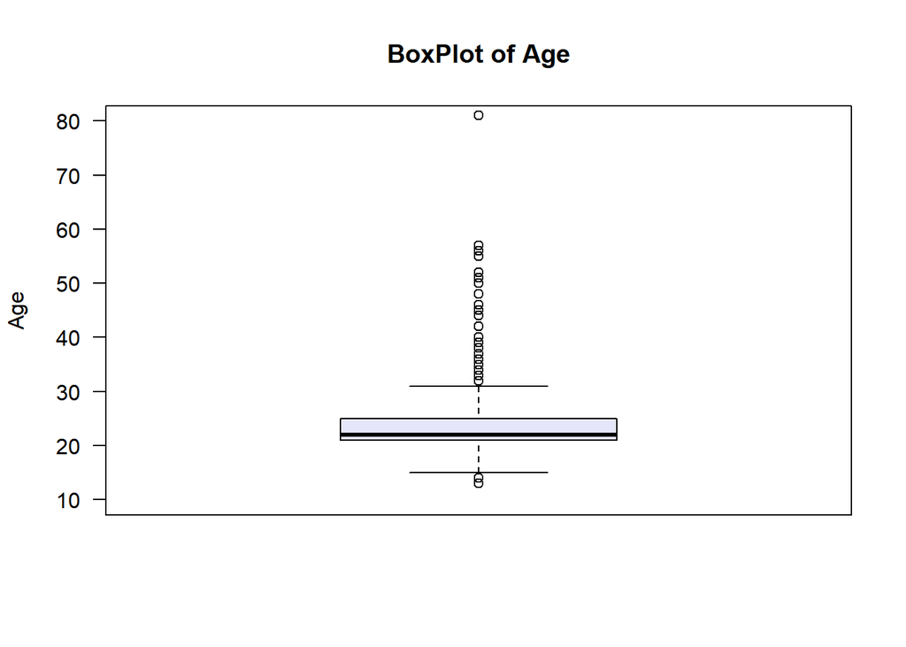

```r
boxplot(Age, ylim=c(10,80), las=1, main="BoxPlot of Age", ylab="Age", col="lavender")
```

```r
fivenum(Age, na.rm = TRUE)
```

```
## [1] 13 21 22 25 81
```

#Box Plot of Photos

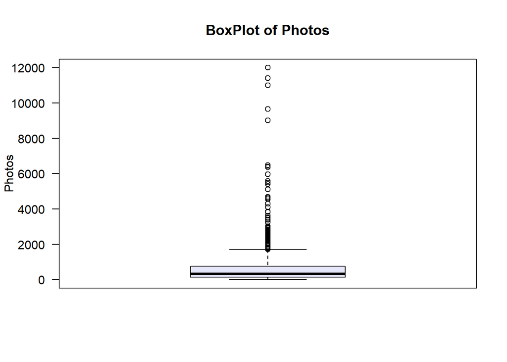

```r
boxplot(Photos, las=1, main="BoxPlot of Photos", ylab="Photos", col="lavender" )
```

```r
fivenum(Photos, na.rm = TRUE)
```

```
## [1]     0.0   124.5   320.0   757.0 11995.0
```

#Box plot of Number of Tags

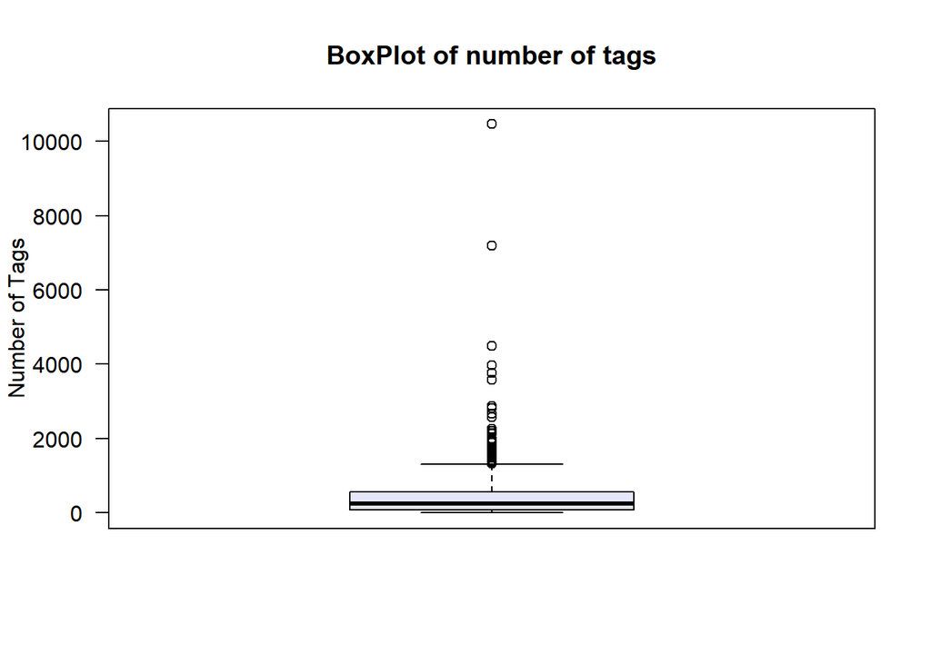

```r
boxplot(X..of.Tags,las=1, main="BoxPlot of number of tags", ylab="Number of Tags", col="lavender")
```

```r
fivenum(X..of.Tags, na.rm = TRUE)
```

```
## [1]     0.0    75.5   250.0   566.5 10460.0
```

#Box Plot of Albums

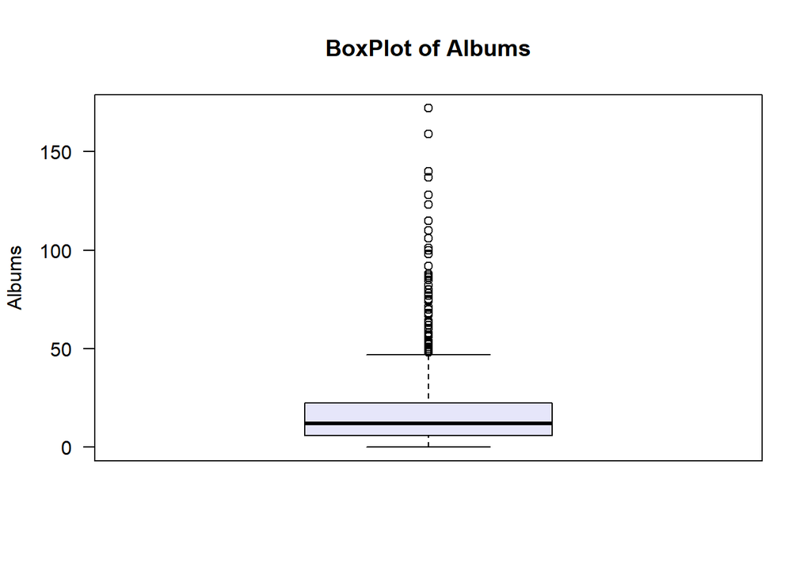

```r
boxplot(Albums, las=1, main="BoxPlot of Albums", ylab="Albums", col="lavender")
```

```r
fivenum(Albums, na.rm = TRUE)
```

```
## [1]   0.0   6.0  12.0  22.5 172.0
```

#Box plot of Posts

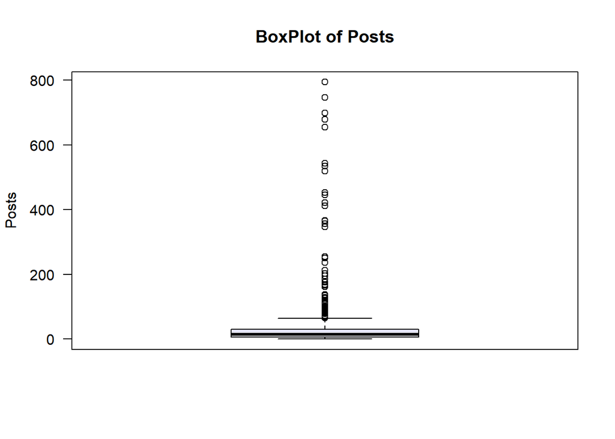

```r
boxplot(Posts, las=1, main="BoxPlot of Posts", ylab="Posts", col="lavender")
```

```r
fivenum(Posts, na.rm = TRUE)
```

```
## [1]   0.0   6.0  15.0  29.5 794.0
```

#Box plot of Replies

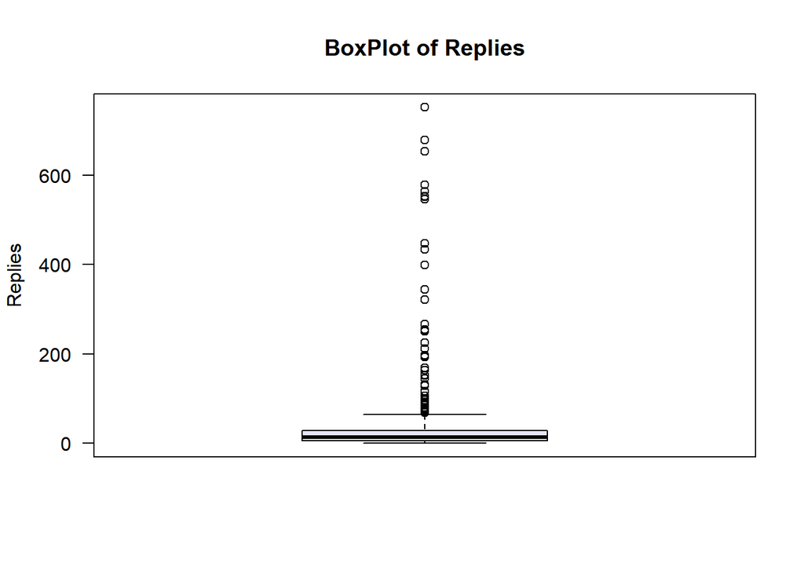

```r
boxplot(Replies, las=1, main="BoxPlot of Replies", ylab="Replies", col="lavender")
```